# Beating the Board: Season Value vs. ADP in PPR Fantasy Football (2017–2023)

## 3.1 Descriptive Models

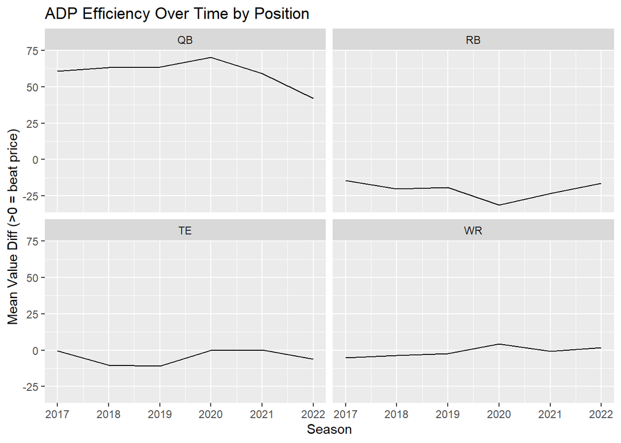

```r
library(ggplot2)
by_year <- df %>%
  group_by(season, position) %>%
  summarize(mean_diff = mean(value_diff, na.rm = TRUE), .groups = "drop")

ggplot(by_year, aes(x = season, y = mean_diff)) +
  geom_line() +
  facet_wrap(~ position) +
  labs(title = "ADP Efficiency Over Time by Position",
       x = "Season", y = "Mean Value Diff (>0 = beat price)")
```

### 3.1.1 Undervalued Players

```r
consistent <- df %>%
  group_by(player, position) %>%
  summarize(
    n_seasons = n(),
    mean_diff = mean(value_diff, na.rm = TRUE),
    sd_diff   = sd(value_diff, na.rm = TRUE),
    median_finish = median(actual_rank, na.rm = TRUE),
    .groups = "drop"
  ) %>%
  filter(n_seasons >= 3) %>%
  arrange(desc(mean_diff))

head(consistent, 15)
```

```
## # A tibble: 15 × 6
##    player             position n_seasons mean_diff sd_diff median_finish
##    <chr>              <chr>        <int>     <dbl>   <dbl>         <dbl>
##  1 Philip Rivers      QB               4      94.9    23.1          31.8
##  2 Kirk Cousins       QB               5      93.7    36.5          20
##  3 Jared Goff         QB               3      86.8    32.8          32
##  4 Carson Wentz       QB               5      79.9    52.0          28
##  5 Derek Carr         QB               4      74.6    37.2          45.5
##  6 Josh Allen         QB               4      71.5    53.1           2
##  7 Joe Burrow         QB               3      66.3    28.4          14
##  8 Ben Roethlisberger QB               5      65.3    69.8          23
##  9 Dak Prescott       QB               6      62.8    68.0          22.8
## 10 Baker Mayfield     QB               3      62.5    45.4          46
## 11 Matt Ryan          QB               6      62.1    26.9          26.5
## 12 Matthew Stafford   QB               6      62      41.2          40.5
## 13 Tom Brady          QB               6      59.3    30.1          16
## 14 Cole Beasley       WR               3      53.3    33.5          91
## 15 Russell Wilson     QB               6      52      20.5          14
```

### 3.1.2 Value Difference by Position

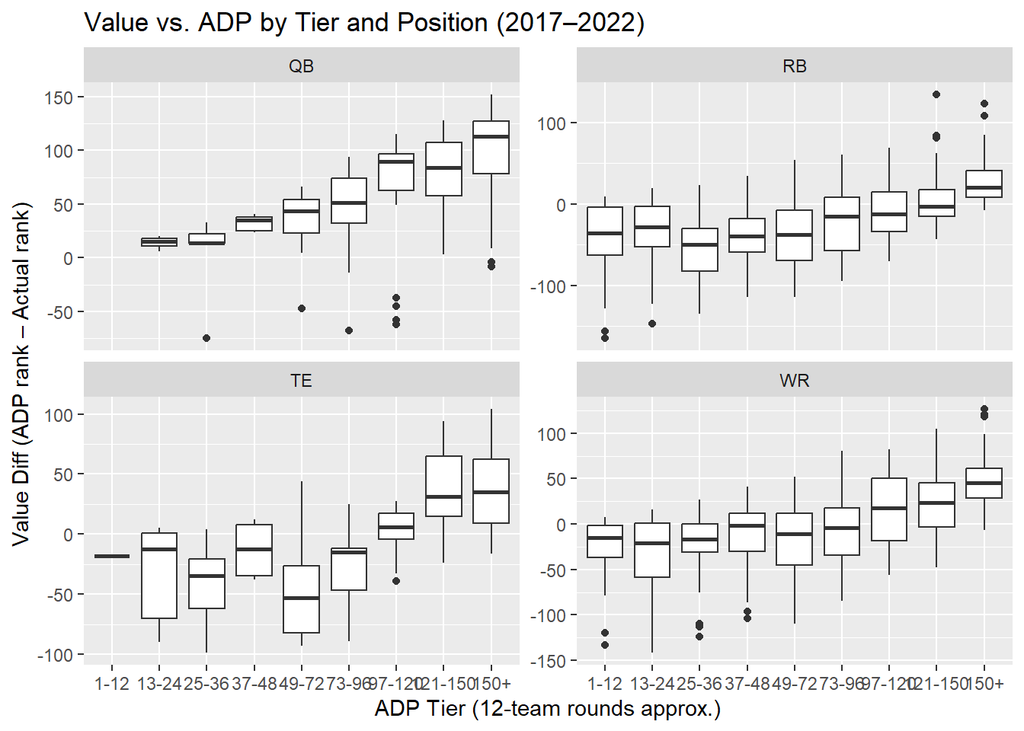

```r
tier_pos <- df %>%
  group_by(adp_tier, position) %>%
  summarize(
    n = n(),
    mean_diff = mean(value_diff, na.rm = TRUE),
    median_diff = median(value_diff, na.rm = TRUE),
    sd_diff = sd(value_diff, na.rm = TRUE),
    .groups = "drop"
  )

ggplot(df, aes(x = adp_tier, y = value_diff)) +
  geom_boxplot() +
  facet_wrap(~ position, scales = "free_y") +
  labs(title = "Value vs. ADP by Tier and Position (2017–2022)",
       x = "ADP Tier (12-team rounds approx.)",
       y = "Value Diff (ADP rank – Actual rank)")
```

### Model M0 baseline expectation to outcome

Concept: quantify the marginal link between ADP and PPR.

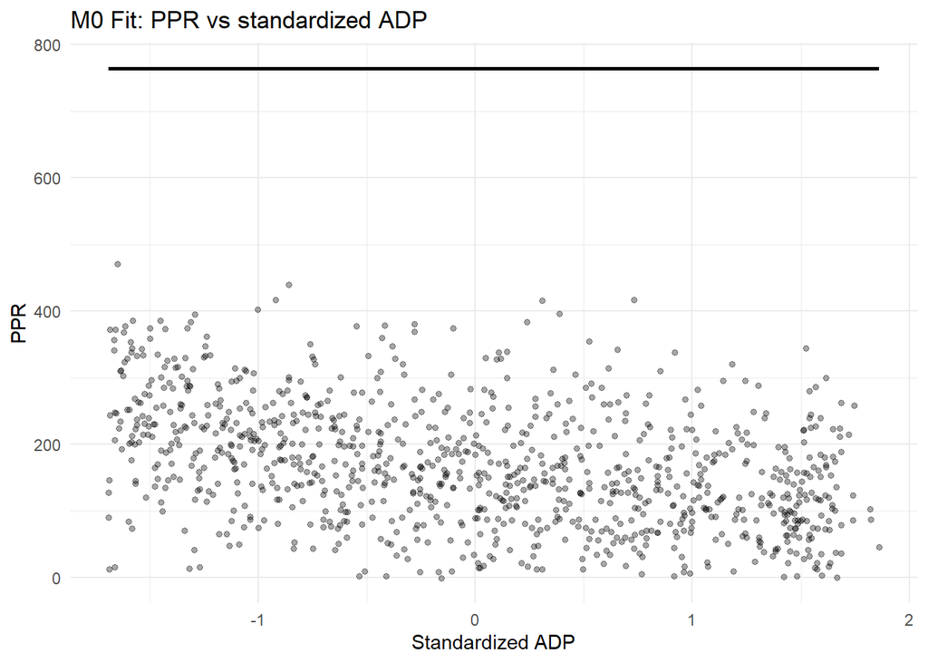

```r
m0 <- quap(
  alist(
    ppr ~ dnorm(mu, sigma),
    mu <- alpha + b_adp * adp_s,
    alpha ~ dnorm(0, 300),   # wider so intercept can sit near mean PPR
    b_adp ~ dnorm(0, 2),
    sigma ~ dexp(1)
  ),
  data = df
)

alpha_hat <- coef(m0)["alpha"]; b_hat <- coef(m0)["b_adp"]
line_df <- data.frame(adp_s = seq(min(df$adp_s), max(df$adp_s), length.out = 100))
line_df$mu <- alpha_hat + b_hat * line_df$adp_s

library(ggplot2)
ggplot(df, aes(adp_s, ppr)) +
  geom_point(alpha=.35, size=1.2) +
  geom_line(data=line_df, aes(adp_s, mu), linewidth=1) +
  labs(title="M0 Fit: PPR vs standardized ADP", x="Standardized ADP", y="PPR") +
  theme_minimal()
```

### 3.1.3 Model M1 add structure for position and season

Concept: absorb systematic differences across roles and seasons implied by the DAG.

```r
library(rethinking)

# Model M1: add position and season structure
m1 <- quap(
  alist(
    ppr ~ dnorm(mu, sigma),
    mu <- alpha +
           b_adp * adp_s +
           b_pos[position_id] +
           b_season[season_id],
    alpha ~ dnorm(0, 300),
    b_adp ~ dnorm(0, 2),
    b_pos[position_id] ~ dnorm(0, 2),
    b_season[season_id] ~ dnorm(0, 2),
    sigma ~ dexp(1)
  ),
  data = df
)
precis(m1, depth = 2)
```

```
##                    mean       sd       5.5%      94.5%
## alpha       170.0670693 2.895465 165.439557 174.694581
## b_adp       -13.9388943 1.623157 -16.533013 -11.344775
## b_pos[1]      6.7220343 1.952679   3.601276   9.842792
## b_pos[2]     -4.4941670 1.887872  -7.511351  -1.476983
## b_pos[3]     -1.6781196 1.945192  -4.786913   1.430673
## b_pos[4]     -0.5418688 1.875160  -3.538736   2.454998
## b_season[1]  -1.4774211 1.923260  -4.551162   1.596320
## b_season[2]   0.7604677 1.920769  -2.309291   3.830227
## b_season[3]   0.1124802 1.919810  -2.955746   3.180707
## b_season[4]  -0.2399484 1.918429  -3.305969   2.826072
## b_season[5]   0.2911272 1.916177  -2.771294   3.353548
## b_season[6]   0.5567116 1.928135  -2.524821   3.638244
## sigma        80.1993312 1.778451  77.357024  83.041639
```

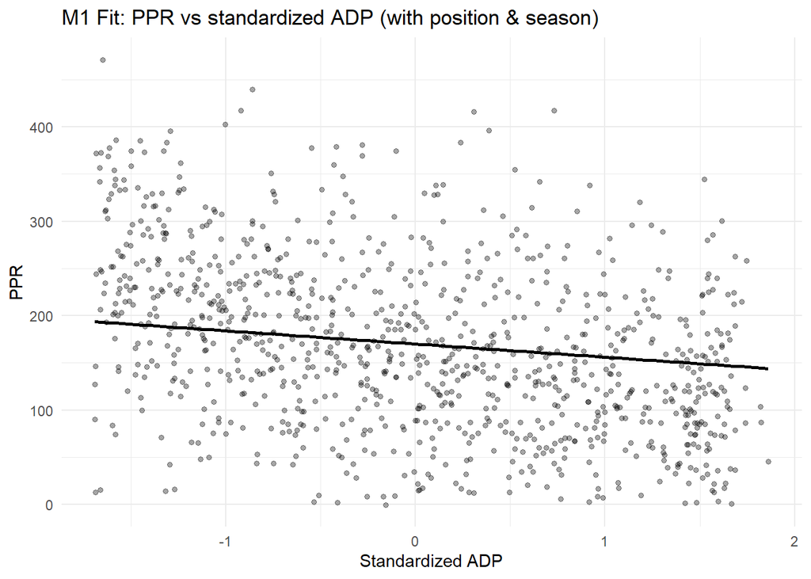

```r
# quick fit line for M1
alpha_hat <- coef(m1)["alpha"]
b_hat     <- coef(m1)["b_adp"]

line_df <- data.frame(
  adp_s = seq(min(df$adp_s, na.rm=TRUE), max(df$adp_s, na.rm=TRUE), length.out = 100)
) |>
  mutate(mu = alpha_hat + b_hat * adp_s)

library(ggplot2)
ggplot(df, aes(adp_s, ppr)) +
  geom_point(alpha = 0.35, size = 1.2) +
  geom_line(data = line_df, aes(adp_s, mu), linewidth = 1) +
  labs(title = "M1 Fit: PPR vs standardized ADP (with position & season)",
       x = "Standardized ADP", y = "PPR") +
  theme_minimal()
```

### 3.1.4 Model M2 add team context to block the backdoor

Concept: control the Team Context path that links ADP and PPR.

```r
# Model M2: add team context to block backdoor path
m2 <- quap(
  alist(
    ppr ~ dnorm(mu, sigma),
    mu <- alpha +
           b_adp * adp_s +
           b_pos[position_id] +
           b_season[season_id] +
           b_team[team_id],
    alpha ~ dnorm(0, 300),
    b_adp ~ dnorm(0, 2),
    b_pos[position_id] ~ dnorm(0, 2),
    b_season[season_id] ~ dnorm(0, 2),
    b_team[team_id] ~ dnorm(0, 2),
    sigma ~ dexp(1)
  ),
  data = df
)
precis(m2, depth = 2)
```

```
##                     mean       sd       5.5%      94.5%
## alpha       170.05811306 2.915549 165.398503 174.717723
## b_adp       -13.93309217 1.622721 -16.526514 -11.339671
## b_pos[1]      6.72814139 1.952644   3.607440   9.848843
## b_pos[2]     -4.50232207 1.887710  -7.519247  -1.485397
## b_pos[3]     -1.68180737 1.945115  -4.790478   1.426863
## b_pos[4]     -0.54845265 1.874988  -3.545046   2.448141
## b_season[1]  -1.47975639 1.923154  -4.553328   1.593815
## b_season[2]   0.76186972 1.920644  -2.307691   3.831430
## b_season[3]   0.10945159 1.919689  -2.958582   3.177485
## b_season[4]  -0.24231382 1.918299  -3.308125   2.823498
## b_season[5]   0.29165923 1.916045  -2.770551   3.353869
## b_season[6]   0.55465101 1.928030  -2.526713   3.636015
## b_team[1]     0.02597931 1.980432  -3.139133   3.191092
## b_team[2]     0.21118790 1.980456  -2.953964   3.376339
## b_team[3]    -0.13326950 1.985010  -3.305699   3.039160
## b_team[4]     0.40375446 1.982234  -2.764238   3.571747
## b_team[5]     0.05138796 1.985004  -3.121031   3.223807
## b_team[6]    -0.18121345 1.982717  -3.349978   2.987551
## b_team[7]     0.17458840 1.983864  -2.996009   3.345186
## b_team[8]    -0.04049893 1.983853  -3.211080   3.130082
## b_team[9]     0.37791623 1.979367  -2.785495   3.541328
## b_team[10]   -0.36008701 1.983331  -3.529833   2.809659
## b_team[11]   -0.02927922 1.980451  -3.194423   3.135865
## b_team[12]    0.20419846 1.978776  -2.958267   3.366664
## b_team[13]    0.23682883 1.985032  -2.935635   3.409293
## b_team[14]   -0.12954831 1.981601  -3.296529   3.037433
## b_team[15]   -0.26567563 1.987358  -3.441858   2.910507
## b_team[16]    0.39806788 1.974964  -2.758305   3.554441
## b_team[17]    0.76772592 1.980693  -2.397803   3.933255
## b_team[18]    0.39006154 1.980504  -2.775167   3.555290
## b_team[19]   -0.12126664 1.983278  -3.290929   3.048395
## b_team[20]   -0.31016207 1.985073  -3.482693   2.862369
## b_team[21]    0.64344471 1.980618  -2.521965   3.808854
## b_team[22]   -0.66271439 1.973982  -3.817519   2.492090
## b_team[23]    0.15913832 1.979876  -3.005087   3.323363
## b_team[24]   -0.28209999 1.985038  -3.454575   2.890375
## b_team[25]   -0.47901653 1.985698  -3.652546   2.694513
## b_team[26]   -0.21388717 1.977659  -3.374568   2.946794
## b_team[27]    0.42999371 1.982781  -2.738874   3.598861
## b_team[28]    0.11682421 1.979874  -3.047398   3.281046
## b_team[29]   -0.75081412 1.979573  -3.914554   2.412926
## b_team[30]    0.06425820 1.975975  -3.093731   3.222248
## b_team[31]   -0.03622366 1.983273  -3.205877   3.133429
## b_team[32]   -0.66403577 1.984625  -3.835850   2.507778
## sigma        80.12265847 1.778450  77.280351  82.964966
```

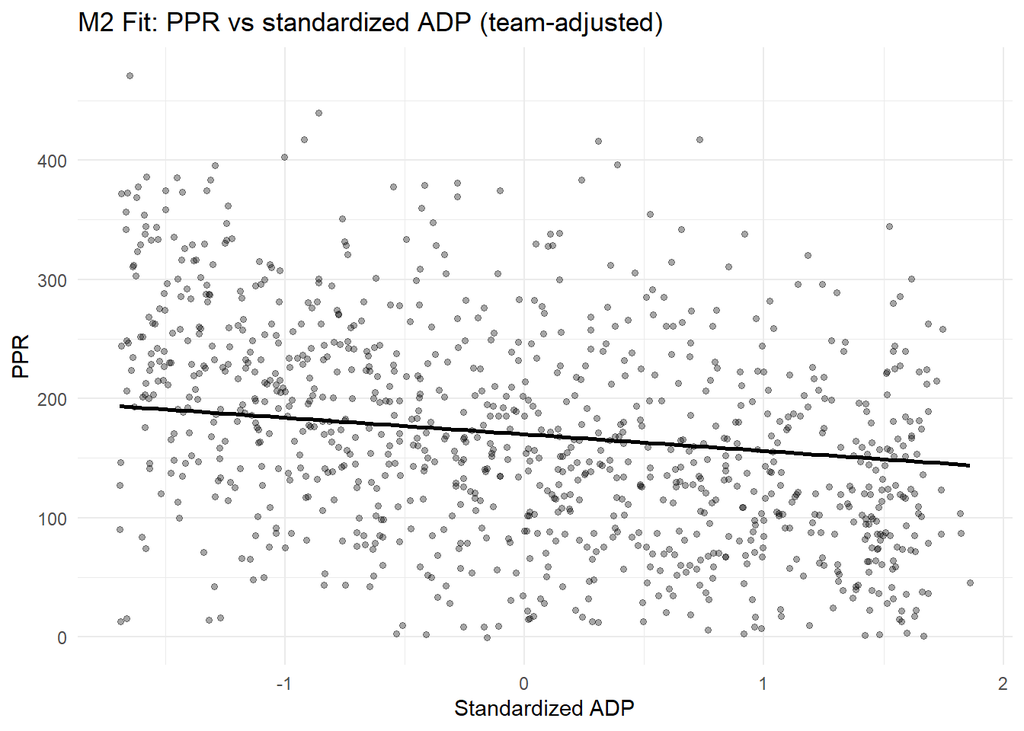

```r
# quick fit line for M2
alpha_hat <- coef(m2)["alpha"]
b_hat     <- coef(m2)["b_adp"]

line_df <- data.frame(
  adp_s = seq(min(df$adp_s, na.rm=TRUE), max(df$adp_s, na.rm=TRUE), length.out = 100)
) |>
  mutate(mu = alpha_hat + b_hat * adp_s)

ggplot(df, aes(adp_s, ppr)) +
  geom_point(alpha = 0.35, size = 1.2) +
  geom_line(data = line_df, aes(adp_s, mu), linewidth = 1) +
  labs(title = "M2 Fit: PPR vs standardized ADP (team-adjusted)",
       x = "Standardized ADP", y = "PPR") +
  theme_minimal()
```

# 4 Learning is inference

Bayesian learning is the process of updating our beliefs about parameters in light of the data. Each of the three models (M0–M2) represents a hypothesis about how pre-season expectations, expressed through Average Draft Position (ADP), relate to actual fantasy football performance. The priors reflect initial uncertainty before observing the data, while the posterior distributions summarize what has been learned after incorporating the evidence.

From a Bayesian perspective, inference is not about accepting or rejecting hypotheses but about learning from the data. The models update our understanding of how well preseason expectations predict reality, with posterior distributions expressing both knowledge and uncertainty. Each step—from M0’s baseline to M1 and M2—represents a refinement in our beliefs about fantasy player performance through probabilistic learning.

# 5 Conclusions

This analysis demonstrates how Bayesian inference can be used to model and interpret relationships between pre-season expectations and actual player performance in fantasy football. By constructing generative models and updating prior beliefs through observed data, we gained probabilistic insight into the predictive value of Average Draft Position. The models show that players drafted earlier tend to outperform those selected later, with credible evidence supporting a negative association between draft rank and realized fantasy output.

# 6 BibTex for References

```r
@article{Lopez2018,
  title   = {How often does the best team win? A unified approach to understanding randomness in North American sport},
  author  = {Lopez, Michael J. and Matthews, Gregory J. and Baumer, Benjamin S.},
  journal = {Annals of Applied Statistics},
  year    = {2018},
  volume  = {12},
  number  = {4},
  pages   = {2483--2516}
}

@article{BeuoyLopez2021,
  title   = {The wisdom of the crowd in fantasy football projections},
  author  = {Beuoy, Bryan and Lopez, Michael J.},
  journal = {Journal of Quantitative Analysis in Sports},
  year    = {2021},
  volume  = {17},
  number  = {1},
  pages   = {25--38}
}

@book{Tetlock2015,
  title     = {Superforecasting: The Art and Science of Prediction},
  author    = {Tetlock, Philip E. and Gardner, Dan},
  year      = {2015},
  publisher = {Crown}
}

@misc{bolduc2023fantasy,
  author       = {Gabriel Bolduc},
  title        = {Fantasy Football Data (2017--2023)},
  year         = {2023},
  howpublished = {\url{https://www.kaggle.com/datasets/gbolduc/fantasy-football-data-2017-2023}},
  note         = {Accessed December 2025}
}
```